# Continuous Random Variables - Answer to Time to Play 4

1. To compute $E(X)$, the mean/expected value of $X$ you to compute the following integral:
   $$\mu_X{} = E(X) = \int_{0}^{\infty} x*e^{-x}dx = ?$$
   This *can* be integrated using integration by parts. Rather than this, use R to (i) create a function that represents $x*e^{-x}$, then use the `integrate` function to compute $E(X)$.

```r
ev2 = function(x){ x*exp(-x)}  #create the function x*e^{-x}
a = integrate(ev2, 0, Inf)$value  #computes E(X) and assigns this to a
a #retunrs the value of expected value/mean
```

```
[1] 1
```

therefore,
$$\mu_X{} = E(X) = \int_{0}^{\infty} x*e^{-x}dx = 1$$
The visualization of the distribution of $X$, $f(x)$, is provided below.

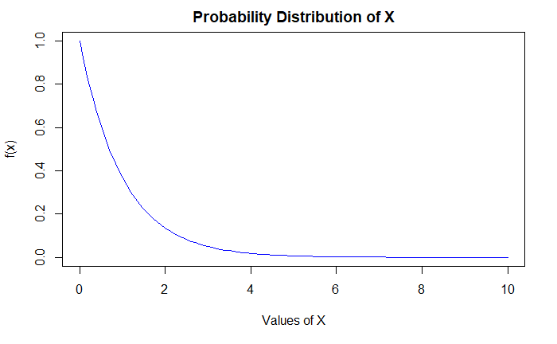

```r
ttppdf4 = function(x){ exp(-x)}  #creates a function for the pdf of x, f(x)
curve(ttppdf4, 0, 10, xlab="Values of X", ylab="f(x)", main="Probability Distribution of X", col='blue')
```

The expected value or mean - a center of gravity of this distibution - or the balancing point is $\mu_{X} = E(X) = 1$.

2. Similar to the steps in part (a), the second moment of $X$ or $E(X^{2})$ is computed with the integral
   $$E(X^2) = \int_{0}^{\infty} x^2*e^{-x}dx = ?$$
   This would require integration by parts *twice*. Following the approach outlined in part (a), R code is writtin to compute $E(X^2)$.

```r
ttp2ndfunc = function(x){x^{2}*exp(-x)}  #create a function that represents x^{2}e^{-x}
ttp4secondmoment = integrate(ttp2ndfunc, lower=0, upper=Inf)$value #computes the 2nd moment and assigns
ttp4secondmoment  #returns value of E(x^2)
```

```
[1] 2
```

and
$$E(X^2) = \int_{0}^{\infty} x^2*e^{-x}dx = 2$$

3. To compute the standard deviation of $X$, $\sigma_{X}$ or $SD(X)$, the variance of $X$ $Var(X)$ is computed first:

```r
ttp4variance = ttp4secondmoment - (a^2)   #E(X^2) - E(X)^{2}
ttp4variance
```

```
[1] 1
```

What has just been computed in R is
$$Var(X) = E(X^{2}) - E(X)^{2} = 2 - 1^{2} = 1$$
Now, take the square root of the variance to get the standard deviation of $X$:

```r
ttp4sd = sqrt(ttp4variance)
ttp4sd
```

```
[1] 1
```

and $\sigma_{X} = SD(X) = 1$.

4. The region that represents $P(X > 1)$ is provided below.

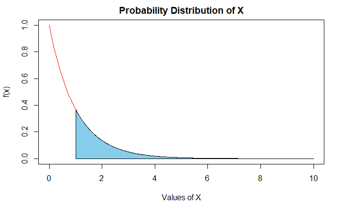

To compute either carry out the integration or use R to do the integration for you. The latter is

```r
integrate(ttppdf4, lower=1, upper=Inf)$value
```

```
[1] 0.3678794
```

5. To compute the conditional probability of $X > 2$ given$ that $X > 1$, you need to compute
   $$P(X > 2|X>1) = \frac{P((X > 2) \cap (X > 1))}{P(X > 1)}$$
   First, consider that $X > 1$, which was computed in part (d) to be $P(X > 1) = 0.3679$. Now, conside the region that is common* to both $X > 1$ and $X > 2$

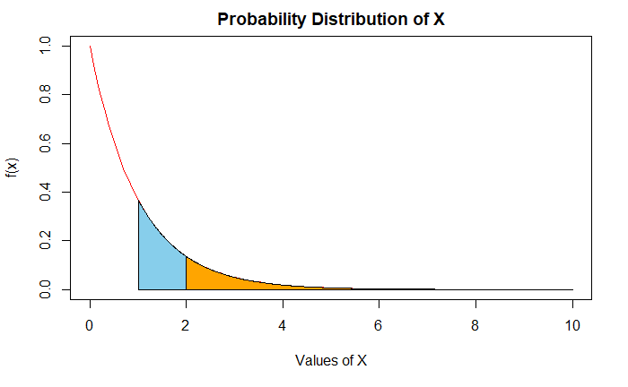

From this graph, it can observed that $X > 1$ $\cap$ $X > 2$ is $X > 2$ and
$$\begin{aligned}
P(X > 2|X>1) = & \frac{P((X > 2) \cap (X > 1))}{P(X > 1)} \\
= & \frac{P(X > 2)}{P(X > 1)} \\
= & \frac{\int_{2}^{\infty} e^{-x}dx}{\int_{1}^{\infty} e^{-x}dx} \hspace{0.5in} \text{OR}\\
= & \frac{1 - P(X \leq 2)}{1 - P(X \leq 1)} \\
= & \frac{1 -F(2)}{1 - F(1)} \hspace{0.5in} (\text{remember that} \:\:F(x) = 1 - e^{-x}) \\
= & \frac{1 - (1 - e^{-2})}{1 - (1 - e^{-1})} \\
= & \frac{0.1353}{0.3679} \\
= & 0.3679
\end{aligned}$$
Below, this compuation is illustrated with R:

```r
ttp4conditionalprob = (integrate(ttppdf4, lower=2, upper=Inf)$value)/(integrate(ttppdf4, lower=1, upper=Inf)$value)  #computes P(X > 2)/P(X > 1)
ttp4conditionalprob
```

```
[1] 0.3678794
```

This is an interesting result. Notice how that $P(X > 2|X > 1) = P(X > 1)$ in this case?